# Text mining. Clusterisation

Что такое иерархическая кластеризация и как она работает?

```r
library(factoextra)
```

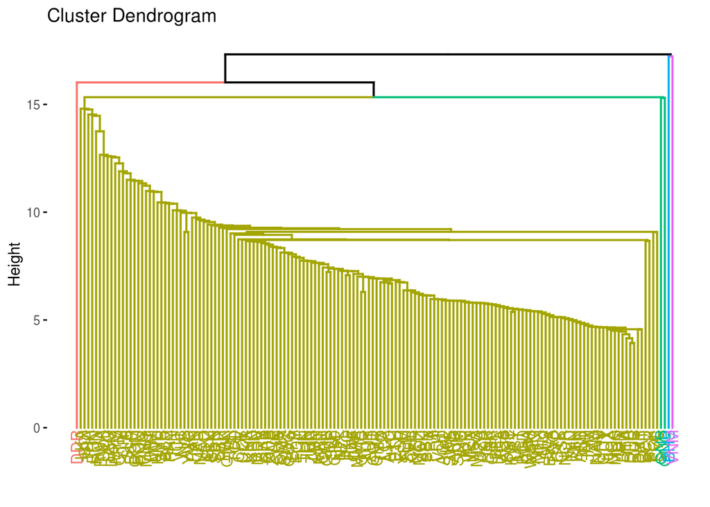

```r
res_single <- hcut(dist(un.tdm_m, method = "euclidean"), hc_method = "single", k = 5, stand = TRUE)
fviz_dend(res_single)
```

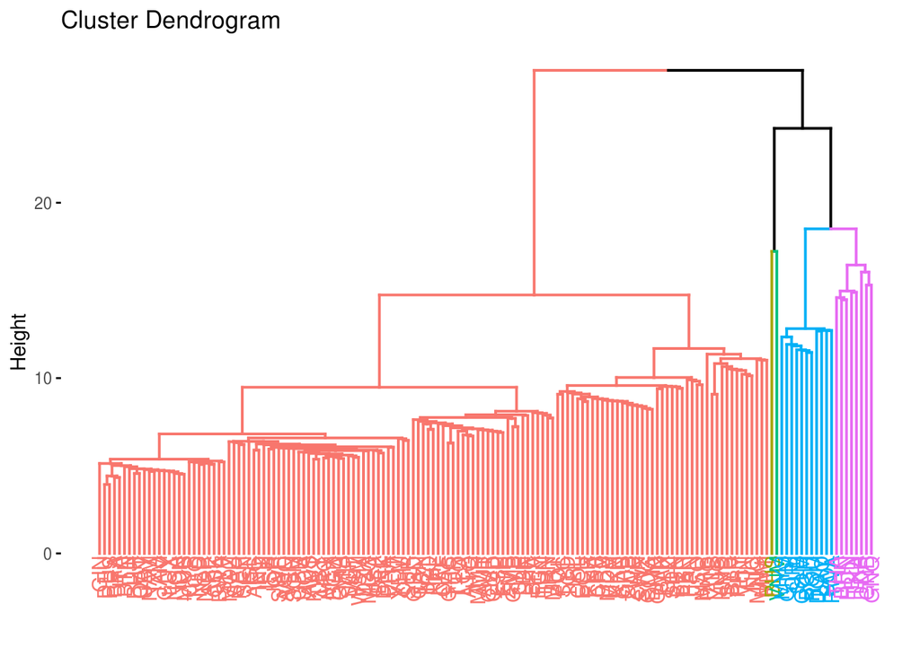

```r
res_average <- hcut(dist(un.tdm_m, method = "euclidean"), hc_method = "average", k = 5, stand = TRUE)
fviz_dend(res_average)
```

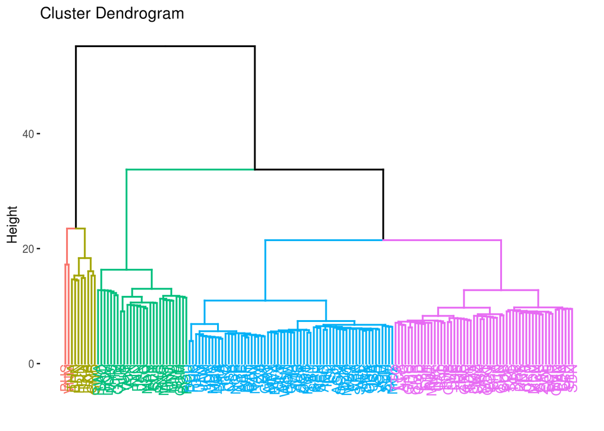

```r
res_complete <- hcut(dist(un.tdm_m, method = "euclidean"), hc_method = "complete", k = 5, stand = TRUE)
fviz_dend(res_complete)
```

Сделаем график чуть красивее

```r
library(dendextend)
```

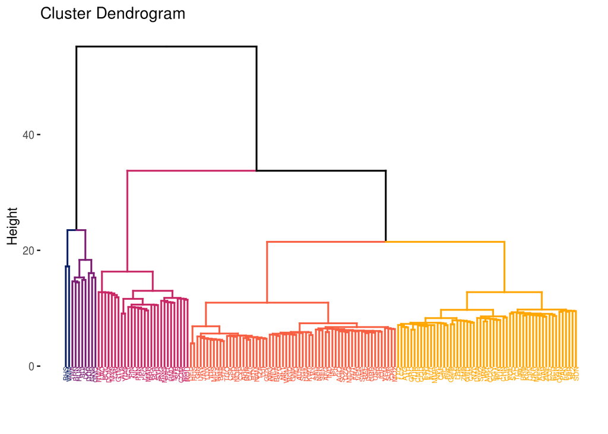

```r
# https://learnui.design/tools/data-color-picker.html -- можно сделать свою палетку
mycols <- c("#0c2065", "#7c1f74", "#c92765", "#f85f42", "#ffa600")

dend <-  as.dendrogram(res_complete) %>%
   set("branches_lwd", 0.7) %>% # Branches line width
   set("branches_k_color", mycols, k = 5) %>% # Color branches by groups
   set("labels_colors", mycols, k = 5) %>%  # Color labels by groups
   set("labels_cex", 0.4) # Change label size
fviz_dend(dend, layout = "rectangle")
```

Посмотрим внимательнее на сами кластеры

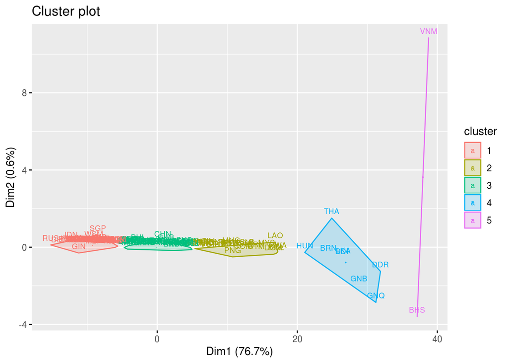

```r
# визуализация в 2-мерном пространстве
fviz_cluster(res_complete, geom = "text", show.clust.cent = TRUE, labelsize = 8)
```

```r
clusters = cbind(un.tdm[1:2], cluster = res_complete$cluster)

# table(clusters$country, clusters$cluster)

# добавим кластер к датасету со словами без стоп-слов, редких и частых слов и посчитаем частые слова внутри кластера
clusters = inner_join(clusters, un_words_no_stop)
```

```r
clusters_top = clusters %>%
  group_by(cluster, word_lemma) %>%
  summarize(total = sum(n)) %>%
  arrange(cluster, -total)

# построим вордклауды по кластерам
library(wordcloud2)
cl1 = clusters_top %>%
  filter(cluster == 1) %>%
  ungroup() %>%
  select(-cluster) %>%
  top_n(50)
wordcloud2(cl1, size = 0.3)
```

[interactive chart not shown]

```r
# о чем этот кластер?


cl2 = clusters_top %>%
  filter(cluster == 2) %>%
  ungroup() %>%
  select(-cluster) %>%
  top_n(50)
```

```r
wordcloud2(cl2, size = 0.3)
```

[interactive chart not shown]

```r
# о чем этот кластер?

cl3 = clusters_top %>%
  filter(cluster == 3) %>%
  ungroup() %>%
  select(-cluster) %>%
  top_n(50)
```

```r
wordcloud2(cl3, size = 0.6)
```

[interactive chart not shown]

```r
# о чем этот кластер?


cl4 = clusters_top %>%
  filter(cluster == 4) %>%
  ungroup() %>%
  select(-cluster) %>%
  top_n(50)
```

```r
wordcloud2(cl4, size = 0.3)
```

[interactive chart not shown]

```r
# о чем этот кластер?


cl5 = clusters_top %>%
  filter(cluster == 5) %>%
  ungroup() %>%
  select(-cluster) %>%
  top_n(50)
```

```r
wordcloud2(cl5, size = 1)
```

[interactive chart not shown]

```r
# о чем этот кластер?
```

Теперь ваша очередь: попробуйте повторить процесс, выделив другой сабкорпус. 1. Выбрать тексты с 57 сессии, сделать иерархическую кластеризацию с 4 кластерами. В каком году проходила эта сессия? 2. Нарисуйте красивую дендраграму 3. Для каждого кластера отобрать из данных соответствующие тексты, найти самые частотные слова кластера. 4. Проинтерпретировать кластеры по часто встречающимся в них словам.

K-means

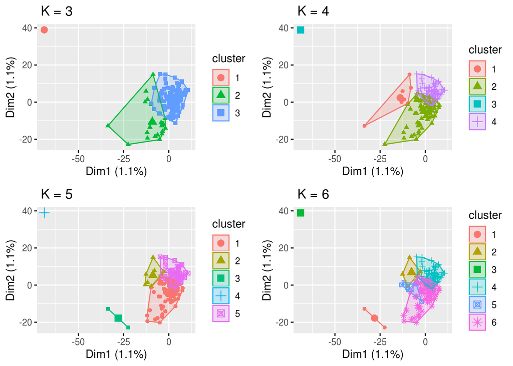

```r
# попробуем посмотреть на модели с разным количеством k
km.out3 = kmeans(scale(un.tdm_m, center = TRUE),3,nstart=5)
km.out4 = kmeans(scale(un.tdm_m, center = TRUE),4,nstart=5)
km.out5=kmeans(scale(un.tdm_m, center = TRUE),5,nstart=5)
km.out6 = kmeans(scale(un.tdm_m, center = TRUE),6,nstart=5)

# наглядно
p1 <- fviz_cluster(km.out3, geom = "point", data = scale(un.tdm_m, center = TRUE)) + ggtitle(" K = 3")
p2 <- fviz_cluster(km.out4, geom = "point", data = scale(un.tdm_m, center = TRUE)) + ggtitle(" K = 4")
p3 <- fviz_cluster(km.out5, geom = "point", data = scale(un.tdm_m, center = TRUE)) + ggtitle(" K = 5")
p4 <- fviz_cluster(km.out6, geom = "point", data = scale(un.tdm_m, center = TRUE)) + ggtitle(" K = 6")

vip::grid.arrange(p1, p2, p3, p4, nrow = 2)
```

```r
# сколько кластеров лучше выбрать?

# fviz_nbclust(x = scale(un.tdm_m, center = TRUE),FUNcluster = kmeans, method = 'silhouette' )
# сколько кластеров лучше выбрать?

# km.out$cluster
km.out4$size
```

```
## [1]  7 84  1 64
```

```r
# table(km.out$cluster)

# посмотрим на получившиеся кластера на графике
pca_comp <- prcomp(scale(un.tdm_m, center = TRUE))
pca_rep <- data_frame(name = un.tdm$country,
                      pc1 = pca_comp$x[,1],
                      pc2 = pca_comp$x[,2],
                      clust_id = as.factor(km.out4$cluster))
```

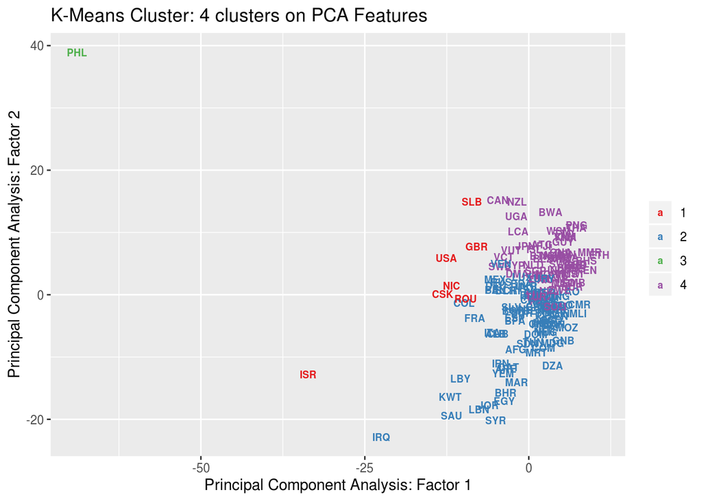

```r
ggplot(data = pca_rep, mapping = aes(x = pc1, y = pc2, color = clust_id)) +
    scale_color_brewer(palette = 'Set1') +
    geom_text(mapping = aes(label = name), size = 2.5, fontface = 'bold') +
    labs(title = 'K-Means Cluster: 4 clusters on PCA Features',
         x = 'Principal Component Analysis: Factor 1',
         y = 'Principal Component Analysis: Factor 2') +
    theme_grey() +
    theme(legend.position = 'right',
          legend.title = element_blank())
```

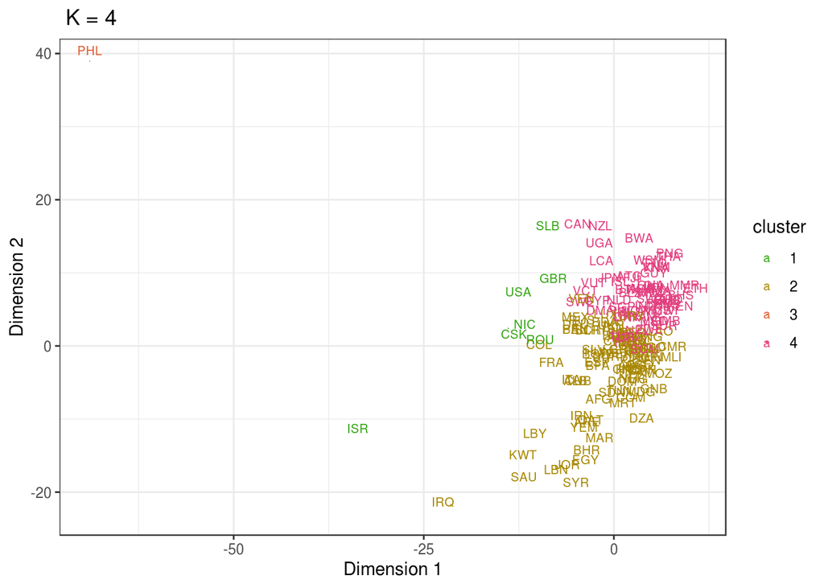

```r
# либо через factoextra

# https://learnui.design/tools/data-color-picker.html -- можно сделать свою палетку
custom_colors = c("#34a513", "#a78700", "#df5a2c", "#e23e7e")

fviz_cluster(km.out4, geom = "text", data = scale(un.tdm_m, center = TRUE), show.clust.cent = TRUE, ellipse = FALSE,labelsize = 8) +
  ggtitle(" K = 4") +
  theme_bw() +
  scale_color_manual(values = custom_colors) +
  xlab("Dimension 1") +
  ylab("Dimension 2")
```

Посмотрим поближе на кластеры

```r
clusters_k = cbind(un.tdm[1:2], cluster = km.out4$cluster)

clusters_k = inner_join(clusters_k, un_words_no_stop)
clusters_k_top = clusters_k %>%
  group_by(cluster, word_lemma) %>%
  summarize(total = sum(n)) %>%
  arrange(cluster, -total)

# посмотрим на частотные слова первых 2-х кластеров
cl1_k = clusters_k_top %>%
  filter(cluster == 1) %>%
  ungroup() %>%
  select(-cluster) %>%
  top_n(50)
```

```r
wordcloud2(cl1_k, size = 0.3)
```

[interactive chart not shown]

```r
# о чем этот кластер?

cl2_k = clusters_k_top %>%
  filter(cluster == 2) %>%
  ungroup() %>%
  select(-cluster) %>%
  top_n(50)
```

```r
wordcloud2(cl2_k, size = 0.3)
```

[interactive chart not shown]

```r
# о чем этот кластер?

cl3_k = clusters_k_top %>%
  filter(cluster == 3) %>%
  ungroup() %>%
  select(-cluster) %>%
  top_n(50)
```

```r
wordcloud2(cl3_k, size = 0.7)
```

[interactive chart not shown]

```r
# о чем этот кластер?

cl4_k = clusters_k_top %>%
  filter(cluster == 4) %>%
  ungroup() %>%
  select(-cluster) %>%
  top_n(50)
```

```r
wordcloud2(cl4_k, size = 0.5)
```

[interactive chart not shown]

```r
# о чем этот кластер?

#похожи ли кластеры по содержанию на те, которые получились в иерархической кластеризации?
```

Опять ваша очередь: повторите процесс на сабкорпусе. 1. Сделайте кластеризацию kmeans на текстах 57 сессии (выберите оптимальное кол-во кластеров в промежутке между 2 и 5). 2. Визуализируйте. 3. Проинтерпретируйте кластеры по частотным словам в них. 4. Сравните результаты иерархической кластеризации и kmeans.

Биграммы.